# Survival Analysis of Post-Myocardial Infarction Patients

### Imputation

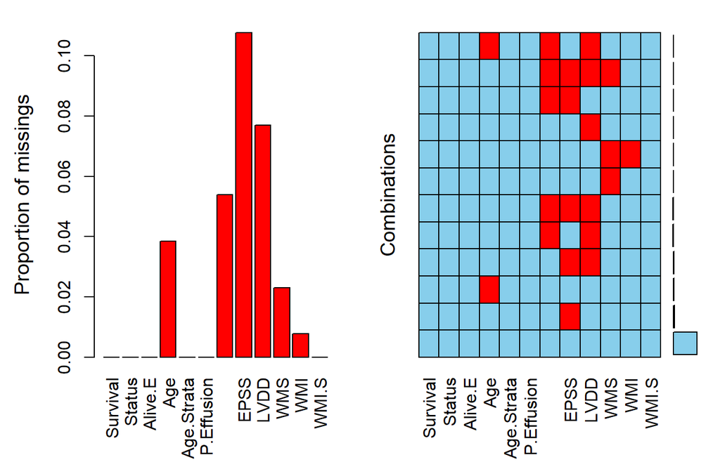

```r
missing.data = aggr(df) # creates a plot to visualize missing information
```

```r
set.seed(7522)
df.i = missForest(df, maxiter = 30, ntree = 1000) # missForest function
```

```
##   missForest iteration 1 in progress...done!
##   missForest iteration 2 in progress...done!
##   missForest iteration 3 in progress...done!
```

```r
round_df <- function(x, digits) {
  # round all numeric variables
  # x: data frame
  # digits: number of digits to round
  numeric_columns <- sapply(x, mode) == 'numeric'
  x[numeric_columns] <-  round(x[numeric_columns], digits)
  x}

df.impute = round_df(df.i$ximp,2) #imputed values table
df.new = df.impute[,c(-5,-12)] #remove incomplete strata from original data
Age.s = ifelse(df.impute$Age < 63,0,1) #new age strata based on imputed data #new age strata based on imputed data
WMS.s = ifelse(df.impute$WMS < 14,0,1) #new WMS strata based on imputed data
Fshort.s = ifelse(df.impute$F.Shortening < 0.2,0,1) #new fshort strata based on imputed data
LVDD.s = ifelse(df.impute$LVDD < 4.75,0,1) #new lvdd strata based on imputed data
EPSS.s = ifelse(df.impute$EPSS < 11.1,0,1)#new epss strata based on imputed data

df.new$Age.s = Age.s
df.new$WMS.s = WMS.s
df.new$F.Short.s = Fshort.s
df.new$LVDD.s = LVDD.s
df.new$EPSS.s = EPSS.s
```

$$NRMSE\ =\ \sqrt{\frac{mean\left(\left(X^{true}-X^{imp}\right)^2\right)}{var\left(X^{true}\right)}}$$

The full imputed dataset may be found in the appendix of this paper. As well as references to the authors who created the algorithm.

### Censoring

Our dataset has numerous censored valued - that is, valued that cannot be recorded due the constraint of the study design. In our data set, we are examining the survival after a heart attack, that is, the event of interest is death given that a patient has had already survived a heart attack (left truncation).

We have fixed start and end dates for when the data was collection. Some patients joined when the study began. Others joined later after the start date. Because of this, we cannot accurately determine how long a patient survived after our observation period is over. In addition, there are some patients that have been lost to follow up or may have died due to the onset of other unrelated factors. These data present themselves as being randomly right censored.

# Methodology

Here, we briefly review the methodology and theory behind our analysis techniques for context.

## Non-Parametric: Kaplan Meier

We use Kaplan-Meier (KM) survival estimators to model a step curve for the survival of our censored dataset. The KM estimator is an adjustment of an empirical survival function to reflect the presence of right-censored observations<sup>14</sup>. The estimator can be described in the following equation:

$$\hat{S}(t) = \prod_{y_{(i)}\leq{t}}^{k} p_i = \prod_{i=1}^{k} (\frac{n_i -d_i}{n_i})$$

$$\hat{S}(t) = \prod_{i=1}^{131} (\frac{n_i -d_i}{n_i})$$

We use this equation to estimate the survival at each time interval. We conduct this analysis for the whole data set and then choose to stratify on age, pericardial effusion presence, and wall motion score. We also include cumulative hazard estimators based on the KM fit. Additionally, as we stratify groups by covariates, we use the Mantel-Haenszel/log-rank test. The following equation is used to calculate the test statistic in order to compare two strata<sup>14</sup>:

$$Mantel-Haenszel \; Statistic = \frac
{\sum_{i=1}^{k} (a_i-E_{0}(A_i))}
{\sqrt{\sum_{i=1}^{k} Var_0 (A_i)}}$$

Where,

$$E_0(A) = \frac{m_1 n_1}{n} \;\; and \;\;\; Var_0(A) =\frac{m_1(n-m_1)}{n-1}*\frac{n_1}{n}(1-\frac{n_1}{n})$$

We then use the Mantel-Haenzel statistics to perform a standard chi-square test to examine the differences between our strata.

### Cumulative Hazard Estimator

We calculate the hazard of our Kaplan-Survivor function by observing standard cumulative hazard estimate (shown below):

$$\hat{H}(t) = -log S(t) = -log \prod_{y_{(i)}\leq{t}} \frac{d_i - n_i}{n_i}$$

Intuitively, the relationship of the observed hazard is the negative log of the survival function at each interval. We can clearly see a graphical relationship between our survival by examining our hazard plots in the results section. There was the possibility of using Nelson-Aalen’s approximation for hazard, but we find that the computation is trivial.

# Semi-Parametric Modeling of Survival Data

Where fully parametric models offer flexibility and the efficient, relatively simple estimation of overall survival function parameters, semi-parametric models offer the advantage of being well-suited to the estimation of covariate effects. Semi-parametric models decompose risk into a baseline hazard component and a relative risk component that is dependent on the covariates.

The semi-parametric Cox proportional hazards model is employed here to explore the relationship between predictor variables and survival behavior.

The Cox PH hazard function is defined as follows:

$$h(t)=h_0(t)exp(b_1x_1+b_2x_2+...+b_nx_n)$$

where t represents the survival time, $x_1,x_2,...,x_n$ are the set of prognostic factors or covariates, and the coefficients $b_1,b_2,...,b_n$ measure the effect of the covariates on survival time. The baseline hazard $h_0(t)$ corresponds to the value of the hazard if all covariates are equal to zero.

Use of the Cox PH model requires that the baseline hazard is not dependent on the covariates, and that the covariate terms do not depend on time - that is, that the slope coefficients are constant. Hazard functions stratified on covariate group may be used to assess the proportional hazard assumption. If the hazards functions for covariate groups cross over time, the proportionality assumption is not met and alternate analysis methods should be employed. One such method involves sub-setting the survival data and covariates based on hazard cross-over time. In this approach, a separate model is fit to each subset where it has been determined that the proportionality assumption holds. Alternately one may apply alternate modeling techniques that are suitable for time-varying effects, or simply investigate the impact of covariate by inspection of stratified Kaplan-Meier survival curves <sup>14</sup>.

# Results

## Non-Parametric: Kaplan-Meier Survival Estimates

Kaplan-Meier estimates give us the following curve (full KM estimator table can be found in the appendix).

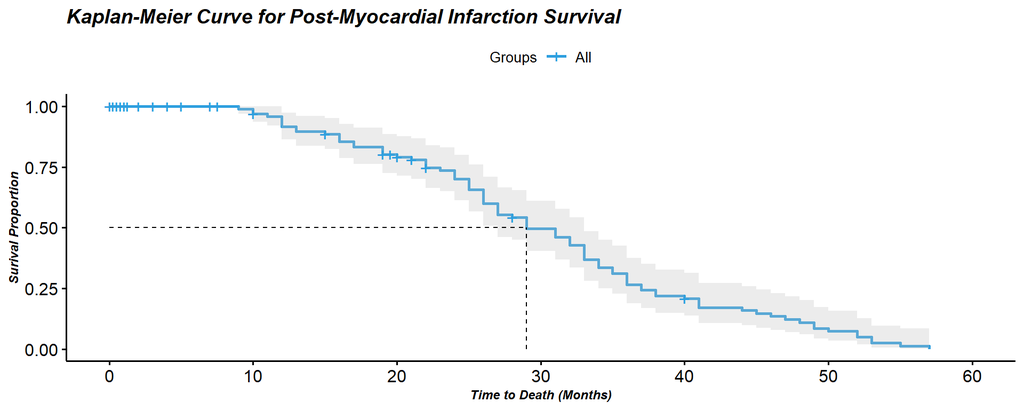

```r
km.all = survfit(s.df~1,type="kaplan-meier", data=df.new)
km.allp = ggsurvplot(km.all,
                           palette = "#2E9FDF",
                           conf.int = TRUE,
                           title="Kaplan-Meier Curve for Post-Myocardial Infarction Survival",
                           font.title=c(14,"bold.italic"),
                           font.subtitle = c(10,"italic"),
                           font.x = c(9, "bold.italic"),
                           font.y = c(9, "bold.italic"),
                           ylab="Surival Proportion",
                           xlab="Time to Death (Months)",
                           surv.median.line = "hv",
                           legend.title = "Groups",
                           legend.labs = "All")
km.allp
```

```r
ks1 = data.frame(t(summary(km.all)$table))
ks1 = ks1[,c(1,4,5,7,8,9)]
colnames(ks1) = c("Records","Events","Mean","Median","Median 0.95 LCL","Median 0.95 UCL")
rownames(ks1) = c("All Groups")

kable(ks1, caption="Kaplan-Meier Estimates for All Groups",align="c", digits=2) %>%
  kable_styling(position = "center", latex_options="hold_position")
```

Kaplan-Meier Estimates for All Groups

|  | Records | Events | Mean | Median | Median 0.95 LCL | Median 0.95 UCL |
| --- | --- | --- | --- | --- | --- | --- |
| All Groups | 130 | 88 | 30.53 | 29 | 27 | 33 |

The Kaplan-Meier estimates for for all groups within our dataset is shown above. The curve follows a general pattern of decreasing survivability over time. With time spanning to a maximum of 57 months, we have a mean survival time of approximately 30.5 months. The median survival time is 29 months with 95% confidence limits between 27 and 33 months.

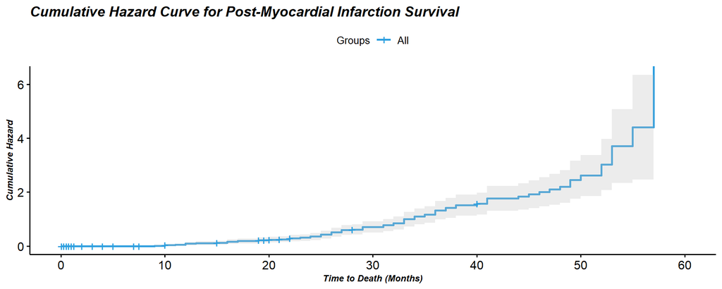

```r
haz.all = ggsurvplot(km.all,
           fun = "cumhaz",
           palette = "#2E9FDF",
           conf.int = TRUE,
           title="Cumulative Hazard Curve for Post-Myocardial Infarction Survival",
           font.title=c(14,"bold.italic"),
           font.subtitle = c(10,"italic"),
           font.x = c(9, "bold.italic"),
           font.y = c(9, "bold.italic"),
           ylab="Cumulative Hazard",
           xlab="Time to Death (Months)",
           legend.title = "Groups",
           legend.labs = "All")

haz.all
```

To explore differences among groups, we stratify among age, pericardial effusion presence, wall motion score, and fractional shortening. We first begin exploring the effects of age and pericardial effusion presence:

### Kaplan-Meier Stratified by Age and Pericardial Effusion Presence

The results of a Kaplan-Meier estimate for age and pericardial effusion stratification can be seen below:

[figure not shown]

```r
km.p1 = list()

km.age = survfit(s.df~Age.s, type="kaplan-meier", data = df.new)
km.p1[[1]] = ggsurvplot(km.age,
                           palette = c("darkcyan","darkgoldenrod3","darkorange3"),
                           subtitle="Survival, Stratified by Age Group",
                           font.subtitle = c(10,"bold.italic"),
                           font.x = c(9, "bold.italic"),
                           font.y = c(9, "bold.italic"),
                           ylab="Surival Proportion",
                           xlab="Time to Death (Months)",
                           surv.median.line = "hv",
                           legend.title = "Groups",
                           legend.labs = c("< 63 Years",">= 63 Years"))

km.effusion = survfit(s.df~P.Effusion, type="kaplan-meier", data = df.new)
km.p1[[2]] = ggsurvplot(km.effusion,
                           palette = c("darkcyan","darkgoldenrod3"),
                           subtitle="Survival, Stratified by Presence of Pericardial Effusion",
                           font.subtitle = c(10,"bold.italic"),
                           font.x = c(9, "bold.italic"),
                           font.y = c(9, "bold.italic"),
                           ylab="Surival Proportion",
                           xlab="Time to Death (Months)",
                           surv.median.line = "hv",
                           legend.title = "Groups",
                           legend.labs = c("Present","Absent"))

arrange_ggsurvplots(km.p1, print=TRUE, ncol=2, nrow=1)
```

```r
ks2 = data.frame(summary(km.age)$table)
ks3 = data.frame(summary(km.effusion)$table)

ks2.3 = rbind(ks2, ks3)
ks2.3 = ks2.3[,c(1,4,5,7,8,9)]
colnames(ks2.3) = c("Records","Events","Mean","Median","Median 0.95 LCL","Median 0.95 UCL")
rownames(ks2.3) = c("Age < 63", "Age >= 63","Absent","Present")

kable(ks2.3, caption="Kaplan-Meier Estimates Stratified by Age and Pericardial Effusion Presence",align="c", digits=2) %>%
  kable_styling(position = "center", latex_options="hold_position")
```

Kaplan-Meier Estimates Stratified by Age and Pericardial Effusion Presence

|  | Records | Events | Mean | Median | Median 0.95 LCL | Median 0.95 UCL |
| --- | --- | --- | --- | --- | --- | --- |
| Age < 63 | 66 | 51 | 30.51 | 29 | 26 | 33 |
| Age >= 63 | 64 | 37 | 30.60 | 32 | 26 | 37 |
| Absent | 106 | 76 | 30.67 | 31 | 27 | 33 |
| Present | 24 | 12 | 29.94 | 27 | 24 | NA |

```r
km.agediff = survdiff(s.df~Age.s, data = df.new)
km.effusiondiff = survdiff(s.df~P.Effusion, data = df.new)

ks2.diff = data.frame(tidy(km.agediff))
ks3.diff = data.frame(tidy(km.effusiondiff))

ks2.diff = ks2.diff[,c(2,3,4)]
ks3.diff = ks3.diff[,c(2,3,4)]
ks2.3diff = rbind(ks2.diff,ks3.diff)
colnames(ks2.3diff) = c("N","Observed","Expected")
rownames(ks2.3diff) = c("Age < 63", "Age >= 63","Absent","Present")

kable(ks2.3diff, caption = "Summary of Differences Between Strata")%>%
  kable_styling(position = "center", latex_options="hold_position")
```

Summary of Differences Between Strata

|  | N | Observed | Expected |
| --- | --- | --- | --- |
| Age < 63 | 66 | 51 | 50.58084 |
| Age >= 63 | 64 | 37 | 37.41916 |
| Absent | 106 | 76 | 76.42260 |
| Present | 24 | 12 | 11.57740 |

Log-rank tests between both stratification groups returns a p-value of 0.9 for both age strata and effusion strata. When testing at the 95% significance level, we do not have significant differences between groups.

[figure not shown]

```r
haz.p1 = list()

haz.p1[[1]] = ggsurvplot(km.age,
           fun = "cumhaz",
           palette = c("darkcyan","darkgoldenrod3"),
           title="Cumulative Hazard, Stratified by Age Group",
           font.title = c(10,"bold.italic"),
           font.x = c(9, "bold.italic"),
           font.y = c(9, "bold.italic"),
           ylab="Cumulative Hazard",
           xlab="Time to Death (Months)",
           legend.title = "Groups",
           legend.labs = c("< 63 Year",">= 63 Years"))

haz.p1[[2]] = ggsurvplot(km.effusion,
           fun = "cumhaz",
           palette = c("darkcyan","darkgoldenrod3"),
           title="Cumulative Hazard, Stratified by Pericardial Effusion Presence",
           font.title = c(10,"bold.italic"),
           font.x = c(9, "bold.italic"),
           font.y = c(9, "bold.italic"),
           ylab="Cumulative Hazard",
           xlab="Time to Death (Months)",
           legend.title = "Groups",
           legend.labs = c("Present","Absent"))

arrange_ggsurvplots(haz.p1, print=TRUE, ncol=2, nrow=1)
```

For both groups, there does not seem to be a large departure from cumulative hazard. When stratifying by age, we see a slight increase in cumulative hazard of the younger group between 30 and 50 months. After that mark, the older group experiences a relative increase in cumulative hazard. When stratified by pericardial effusion presence, very little difference can be observed with any difference being the result of sample size differences.

### Kaplan-Meier Stratified by Wall Motion Score and Fractional Shortening Ratio:

We then explore the effects of wall motion score and fractional shortening:

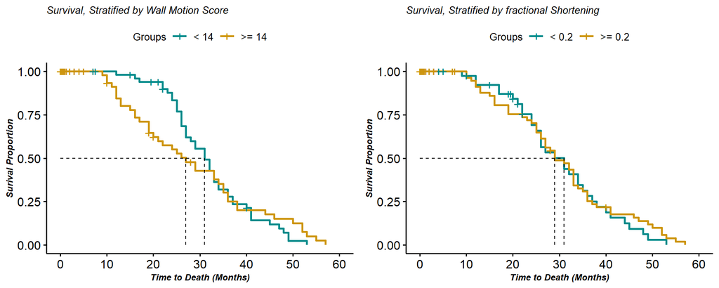

```r
km.p2 = list()

km.wms = survfit(s.df~WMS.s, type="kaplan-meier", data = df.new)
km.p2[[1]] = ggsurvplot(km.wms,
                           palette = c("darkcyan","darkgoldenrod3","darkorange3"),
                           subtitle="Survival, Stratified by Wall Motion Score",
                           font.subtitle = c(10,"italic"),
                           font.x = c(9, "bold.italic"),
                           font.y = c(9, "bold.italic"),
                           ylab="Surival Proportion",
                           xlab="Time to Death (Months)",
                           surv.median.line = "hv",
                           legend.title = "Groups",
                           legend.labs = c("< 14",">= 14"))

km.fshort = survfit(s.df~Fshort.s, type="kaplan-meier", data = df.new)
km.p2[[2]] = ggsurvplot(km.fshort,
                           palette = c("darkcyan","darkgoldenrod3"),
                           subtitle="Survival, Stratified by fractional Shortening",
                           font.subtitle = c(10,"italic"),
                           font.x = c(9, "bold.italic"),
                           font.y = c(9, "bold.italic"),
                           ylab="Surival Proportion",
                           xlab="Time to Death (Months)",
                           surv.median.line = "hv",
                           legend.title = "Groups",
                           legend.labs = c("< 0.2",">= 0.2"))

arrange_ggsurvplots(km.p2, print=TRUE, ncol=2, nrow=1)
```

```r
ks4 = data.frame(summary(km.wms)$table)
ks5 = data.frame(summary(km.fshort)$table)

ks4.5 = rbind(ks4, ks5)
ks4.5 = ks4.5[,c(1,4,5,7,8,9)]
colnames(ks4.5) = c("Records","Events","Mean","Median","Median 0.95 LCL","Median 0.95 UCL")
rownames(ks4.5) = c("Score < 14", "Score >= 14","Ratio < 0.2", "Ratio >= 0.2")

kable(ks4.5, caption="Kaplan-Meier Estimates Stratified by Wall Motion Score and fractional Shortening",align="c", digits=2) %>%
  kable_styling(position = "center", latex_options="hold_position")
```

Kaplan-Meier Estimates Stratified by Wall Motion Score and fractional Shortening

|  | Records | Events | Mean | Median | Median 0.95 LCL | Median 0.95 UCL |
| --- | --- | --- | --- | --- | --- | --- |
| Score < 14 | 62 | 46 | 32.17 | 31 | 27 | 34 |
| Score >= 14 | 68 | 42 | 28.66 | 27 | 20 | 35 |
| Ratio < 0.2 | 61 | 33 | 30.45 | 31 | 26 | 36 |
| Ratio >= 0.2 | 69 | 55 | 30.48 | 29 | 26 | 33 |

```r
km.wmsdiff = survdiff(s.df~WMS.s, data = df.new)
km.f.shortdiff = survdiff(s.df~Fshort.s, data = df.new)

ks4.diff = data.frame(tidy(km.wmsdiff))
ks5.diff = data.frame(tidy(km.f.shortdiff))

ks4.diff = ks4.diff[,c(2,3,4)]
ks5.diff = ks5.diff[,c(2,3,4)]
ks4.5diff = rbind(ks4.diff,ks5.diff)
colnames(ks4.5diff) = c("N","Observed","Expected")
rownames(ks4.5diff) = c("Wall Motion Score < 14", "Wall Motion Score >= 14","Fractional Shortening < 0.2", "Fractional Shortening >= 0.2")

kable(ks4.5diff, caption = "Summary of Differences Between Strata")%>%
  kable_styling(position = "center", latex_options="hold_position")
```

Summary of Differences Between Strata

|  | N | Observed | Expected |
| --- | --- | --- | --- |
| Wall Motion Score < 14 | 62 | 46 | 46.76057 |
| Wall Motion Score >= 14 | 68 | 42 | 41.23943 |
| Fractional Shortening < 0.2 | 61 | 33 | 30.98374 |
| Fractional Shortening >= 0.2 | 69 | 55 | 57.01626 |

When stratified by fractional shortening ratio, both groups have a similar mean at approximately 30.4 months. When fractional shortening is less than 0.2, the median survival time is 31 months while having a fractional shortening ratio that is greater than 0.2, we have a slightly lower median survival time of 29 months.

Log-rank tests to test differences between wall motion score strata show p-value of 0.9 while the same test produces a p-value of 0.6 for fractional shortening. Both of these failures fail to reject the null hypothesis at the 95% significance level. As such, there is no significant difference between either strata groupings.

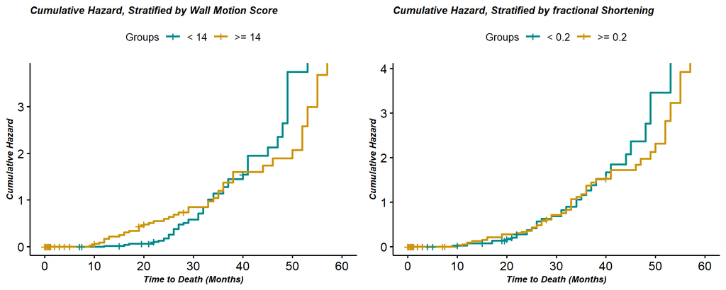

```r
haz.p2 = list()

haz.p2[[1]] = ggsurvplot(km.wms,
           fun = "cumhaz",
           palette = c("darkcyan","darkgoldenrod3"),
           title="Cumulative Hazard, Stratified by Wall Motion Score",
           font.title = c(10,"bold.italic"),
           font.x = c(9, "bold.italic"),
           font.y = c(9, "bold.italic"),
           ylab="Cumulative Hazard",
           xlab="Time to Death (Months)",
           legend.title = "Groups",
           legend.labs = c("< 14",">= 14"))

haz.p2[[2]] = ggsurvplot(km.fshort,
           fun = "cumhaz",
           palette = c("darkcyan","darkgoldenrod3"),
           title="Cumulative Hazard, Stratified by fractional Shortening",
           font.title = c(10,"bold.italic"),
           font.x = c(9, "bold.italic"),
           font.y = c(9, "bold.italic"),
           ylab="Cumulative Hazard",
           xlab="Time to Death (Months)",
           legend.title = "Groups",
           legend.labs = c("< 0.2",">= 0.2"))

arrange_ggsurvplots(haz.p2, print=TRUE, ncol=2, nrow=1)
```

Here, we see some minute differences between the hazard curves. When stratified by Wall Motion Score, we see some overlap in the initial stages of the study as well as around approximately 35 months. The exceptions are seen with higher wall motion scores seeing increased risk before the median and decreased relative risk after the median. The converse is seen for the lower wall motion scores.

When stratified by fractional shortening, the cumulative hazard curves are approximately similar with higher fractional shortening ratios have less risk after the median.

## Regression Analysis - Cox Proportional Hazard Modeling

A model employing all of the covariates listed above was created. In order to test validity of the proportional hazard assumption, survival curves stratified by group were assessed for each of the four selected covariates. It was found that the proportional hazard assumption does not hold, as hazards for each group cross over with time for each covariate.

This limitation was addressed through the identification of survival time subsets in which covariates met the proportional hazards assumption, and could thus be employed as predictor variables. These subsets were identified by inspecting hazard function data stratified on all covariates and identifying regions of crossover.

Model residual diagnostics were assessed for all three models. Models 1 and 2 showed overall good fit to the data and demonstrated proportional hazard assumption compliance. As expected given the discussion above, Model 3 did not result in a good overall fit, although proportional hazard assumption was met. Model diagnostic residual plots and further discussion may be found in the Appendix.

# Discussion of Results, Analysis, and Further Recommendations

## Summary of Limitations

Very clearly, our data is smaller than we hoped for, both in the number of observations and in the availability of meaningful prognostic factors. Development of a single large regression fit that reliably predicts covariates would require a much larger dataset. In particular, the lack of gender as an available covariate is a potential limitation of our data, as the effect of gender on heart-related survival is well established in the literature. Longer collection period over a greater number of patients would yield stronger regression model development. As-is, there is not enough data to produce a significant model across the entire survival time window.

A particular limitation related to subgroup dimension was identified through the stratification analysis. Examination of stratified data showed relative unequal distributions among groups. For example, when examining pericardial effusion, we compare 106 records of with effusion absent to 24 records of effusion present. Given that the collection methods are unclear and the groups sizes are so much different form each other, we cannot fully be confident in our results. Such comparisons are unequal comparisons.